# Beers and Breweries Analysis

Kebur Fantahun, Ricco Ferraro

03/07/2021

# Introduction

With the pandemic in full swing, craft breweries across the nation are closing their doors. Social distancing and other precautionary stay at home orders have forever changed the market for craft beer. This presents a unique opportunity to Anheuser-Busch InBev. In many ways, the market is wide open. Craft beer, especially IPA’s and ales in the US can be shown to follow certain trends with regards to bitterness and ABV. Adhering to these trends may help ensure, when choosing which breweries to procure for example, that an investment is successful.

With the craft beer data provided by Anheuser-Busch InBev, this report will depict the apparent relationship between alcohol by volume(ABV) and international bitterness units(IBU) for myriad beers across the United States. The report also provides summary statistics such as minimums, medians and maximums with respect to ABV and IBU, as well as a deeper look in to the difference between IPA’s and “Other Ale’s”(any beer with Ale in the name) with respect to ABV and IBU. Our analysis reveals information that could be useful to Anheuser-Busch InBev concerning beer volumes in ounces as they relate to each state of the US.

### Dataset

The beers and breweries dataset provided by Anheuser-Busch InBev contain information about 2410 US craft beers and 558 US breweries. The datasets are as follows:

**Beers.csv:**  
* Name: Name of the beer.  
* Beer_ID: Unique identifier of the beer.  
* ABV: Alcohol by volume of the beer.  
* IBU: International Bitterness Units of the beer.  
* Brewery_ID: Brewery id associated with the beer.  
* Style: Style of the beer.  
* Ounces: Ounces of beer.

**Breweries.csv:**  
* Brew_ID: Unique identifier of the brewery.  
* Name: Name of the brewery.  
* City: City where the brewery is located.  
* State: U.S. State where the brewery is located.

### Problem statment

This report is tasked with:  
* analyzing the number of breweries in each state in the US  
* correcting missing IBU Data  
* analyzing minimum, median, and maximum ABV and IBU for each state  
* providing general summary statistics for ABV  
* determining if a relationship between IBU and ABV exists  
* analyzing the IBU and ABV relationship for IPA’s vs other Ales  
* providing other meaningful insight

# Libraries

[output not shown]

[output not shown]

### Import Data

*Note: we use the merge data in Question 1 and therefore we need to perform step 2 first.*

# 2. Merge beer data first with the breweries data & Print first 6 and last 6 oservations in merged file.

| Brewery_id | Drink_name | Beer_ID | ABV | IBU | Style | Ounces | Brewery | City | State |
| --- | --- | --- | --- | --- | --- | --- | --- | --- | --- |
| 1 | Get Together | 2692 | 0.045 | 50 | American IPA | 16 | NorthGate Brewing | Minneapolis | MN |
| 1 | Maggie’s Leap | 2691 | 0.049 | 26 | Milk / Sweet Stout | 16 | NorthGate Brewing | Minneapolis | MN |
| 1 | Wall’s End | 2690 | 0.048 | 19 | English Brown Ale | 16 | NorthGate Brewing | Minneapolis | MN |
| 1 | Pumpion | 2689 | 0.060 | 38 | Pumpkin Ale | 16 | NorthGate Brewing | Minneapolis | MN |
| 1 | Stronghold | 2688 | 0.060 | 25 | American Porter | 16 | NorthGate Brewing | Minneapolis | MN |
| 1 | Parapet ESB | 2687 | 0.056 | 47 | Extra Special / Strong Bitter (ESB) | 16 | NorthGate Brewing | Minneapolis | MN |

|  | Brewery_id | Drink_name | Beer_ID | ABV | IBU | Style | Ounces | Brewery | City | State |
| --- | --- | --- | --- | --- | --- | --- | --- | --- | --- | --- |
| 2405 | 556 | Pilsner Ukiah | 98 | 0.055 | NA | German Pilsener | 12 | Ukiah Brewing Company | Ukiah | CA |
| 2406 | 557 | Heinnieweisse Weissebier | 52 | 0.049 | NA | Hefeweizen | 12 | Butternuts Beer and Ale | Garrattsville | NY |
| 2407 | 557 | Snapperhead IPA | 51 | 0.068 | NA | American IPA | 12 | Butternuts Beer and Ale | Garrattsville | NY |
| 2408 | 557 | Moo Thunder Stout | 50 | 0.049 | NA | Milk / Sweet Stout | 12 | Butternuts Beer and Ale | Garrattsville | NY |
| 2409 | 557 | Porkslap Pale Ale | 49 | 0.043 | NA | American Pale Ale (APA) | 12 | Butternuts Beer and Ale | Garrattsville | NY |
| 2410 | 558 | Urban Wilderness Pale Ale | 30 | 0.049 | NA | English Pale Ale | 12 | Sleeping Lady Brewing Company | Anchorage | AK |

# 1. How many breweries are in each state?

There are a range of breweries for state and they are visible in the state. This could be due to a variety of reasons such as taxation, availability and cost of materials, releastate, demographics or that state etc. In our dataset, Colorado for example has 47 craft breweries and California has 39 craft breweries and Arizona has 11. This dataset obviously does not represent all craft breweries in the state, so it is important to note that it is the relative proportion of craft breweries we are interested in here. In many cases, the craft brewery number is most likely tied to state population. See the Pie chart for the breakdown. See Table:

|  | State | unique_breweries |
| --- | --- | --- |
| 1 | AK | 7 |
| 2 | AL | 3 |
| 3 | AR | 2 |
| 4 | AZ | 11 |
| 5 | CA | 39 |
| 6 | CO | 47 |
| 7 | CT | 8 |
| 8 | DC | 1 |
| 9 | DE | 2 |
| 10 | FL | 15 |

[output cut: 41 more lines]

```
## [1] "Total Unique Breweries: "
```

```
## [1] 558
```

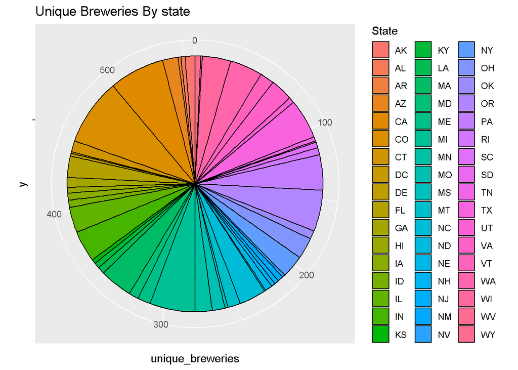

# 3. Assess missing data

## Plot missing data for reference

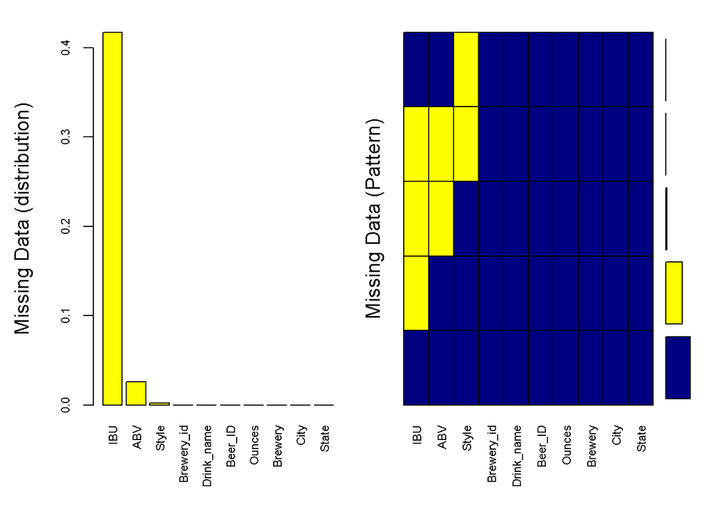

```
##
##  Variables sorted by number of missings:
##    Variable       Count
##         IBU 0.417012448
##         ABV 0.025726141
##       Style 0.002074689
##  Brewery_id 0.000000000
##  Drink_name 0.000000000
##     Beer_ID 0.000000000
##      Ounces 0.000000000
##     Brewery 0.000000000
##        City 0.000000000
##       State 0.000000000
```

```
##    Brewery_id     Drink_name           Beer_ID            ABV
##  Min.   :  1.0   Length:2410        Min.   :   1.0   Min.   :0.00100
##  1st Qu.: 94.0   Class :character   1st Qu.: 808.2   1st Qu.:0.05000
##  Median :206.0   Mode  :character   Median :1453.5   Median :0.05600
##  Mean   :232.7                      Mean   :1431.1   Mean   :0.05977
##  3rd Qu.:367.0                      3rd Qu.:2075.8   3rd Qu.:0.06700
##  Max.   :558.0                      Max.   :2692.0   Max.   :0.12800
##                                                      NA's   :62
##       IBU            Style               Ounces        Brewery
##  Min.   :  4.00   Length:2410        Min.   : 8.40   Length:2410
##  1st Qu.: 21.00   Class :character   1st Qu.:12.00   Class :character
##  Median : 35.00   Mode  :character   Median :12.00   Mode  :character
##  Mean   : 42.71                      Mean   :13.59
##  3rd Qu.: 64.00                      3rd Qu.:16.00
##  Max.   :138.00                      Max.   :32.00
##  NA's   :1005
##      City               State
##  Length:2410        CO     : 265
##  Class :character   CA     : 183
##  Mode  :character   MI     : 162
##                     IN     : 139
##                     TX     : 130
##                     OR     : 125
##                     (Other):1406
```

### Remove Data for entries missing both IBU and ABV when there is no data online

1. Special Release, The Crowler^tm, Can’d aid foundation are missing ABV/IBU/Style
2. Cedar creek - Special Release is ambiguous, missing ABV/IBU/Style and will be dropped as it does not solve the QOI.
3. Oskar Blues Brewery - The Crowler is not an actual beer but a type of can
4. Oskar Blues Brewery - Can’d aid foundation is a relief effort that sends water so it does not fit in the dataset.
5. Beer ID 2364, Royal Lager of Weston Brewing has no ABV/IBU
6. Same for BID - 2322 Fort Pitt Brewing Company Fort Pitt Ale
7. Oskar Blues Brewery Birth IPA, 1750
8. 710, no data
9. MillKing It Productions AXL Pale Ale, 273 - out of business no info
10. 1095 no data
11. 963 no data

### Hand enter all data missing `IBU` AND `ABV`. Note: this data was all available publicly

- Add style data for 2527 and 1635 by looking it up by hand.
- Add IBU and ABV Data for many missing rows by looking up by hand (online via `BeerAdvocate.com` or `Untappd.com`)

```
## Matching, by = "Beer_ID"
```

### Impute IBU based on Median IBU by style for entries that ONLY lack IBU data

|  | Brewery_id | ABV | IBU | Drink_name | Style | Ounces | Brewery | City | State |
| --- | --- | --- | --- | --- | --- | --- | --- | --- | --- |
|  | Min. : 1.0 | Min. :0.00100 | Min. : 3.57 | Length:2400 | Length:2400 | Min. : 8.40 | Length:2400 | Length:2400 | CO : 261 |
|  | 1st Qu.: 94.0 | 1st Qu.:0.05000 | 1st Qu.: 21.00 | Class :character | Class :character | 1st Qu.:12.00 | Class :character | Class :character | CA : 183 |
|  | Median :206.5 | Median :0.05600 | Median : 35.00 | Mode :character | Mode :character | Median :12.00 | Mode :character | Mode :character | MI : 161 |
|  | Mean :232.6 | Mean :0.05969 | Mean : 42.59 | NA | NA | Mean :13.58 | NA | NA | IN : 139 |
|  | 3rd Qu.:367.0 | 3rd Qu.:0.06700 | 3rd Qu.: 64.00 | NA | NA | 3rd Qu.:16.00 | NA | NA | TX : 129 |
|  | Max. :558.0 | Max. :0.12800 | Max. :138.00 | NA | NA | Max. :32.00 | NA | NA | OR : 125 |
|  | NA | NA | NA’s :976 | NA | NA | NA | NA | NA | (Other):1402 |

```
##  [1] Style               Brewery_id          ABV
##  [4] Drink_name          Ounces              Brewery
##  [7] City                State               median_IBU_by_style
## [10] IBU.clean
## <0 rows> (or 0-length row.names)
```

|  | Style | Brewery_id | ABV | Drink_name | Ounces | Brewery | City | State | median_IBU_by_style | IBU.clean |
| --- | --- | --- | --- | --- | --- | --- | --- | --- | --- | --- |
|  | Length:2348 | Min. : 1 | Min. :0.02700 | Length:2348 | Min. : 8.40 | Length:2348 | Length:2348 | CO : 258 | Min. : 8.00 | Min. : 3.57 |
|  | Class :character | 1st Qu.: 92 | 1st Qu.:0.05000 | Class :character | 1st Qu.:12.00 | Class :character | Class :character | CA : 181 | 1st Qu.:21.00 | 1st Qu.: 21.00 |
|  | Mode :character | Median :204 | Median :0.05600 | Mode :character | Median :12.00 | Mode :character | Mode :character | MI : 146 | Median :30.00 | Median : 32.00 |
|  | NA | Mean :231 | Mean :0.05967 | NA | Mean :13.56 | NA | NA | IN : 139 | Mean :40.03 | Mean : 40.46 |
|  | NA | 3rd Qu.:366 | 3rd Qu.:0.06700 | NA | 3rd Qu.:16.00 | NA | NA | TX : 129 | 3rd Qu.:69.00 | 3rd Qu.: 60.00 |
|  | NA | Max. :558 | Max. :0.12800 | NA | Max. :32.00 | NA | NA | OR : 115 | Max. :96.00 | Max. :138.00 |
|  | NA | NA | NA | NA | NA | NA | NA | (Other):1380 | NA | NA |

### Plot missing data to show it has all been resolved.

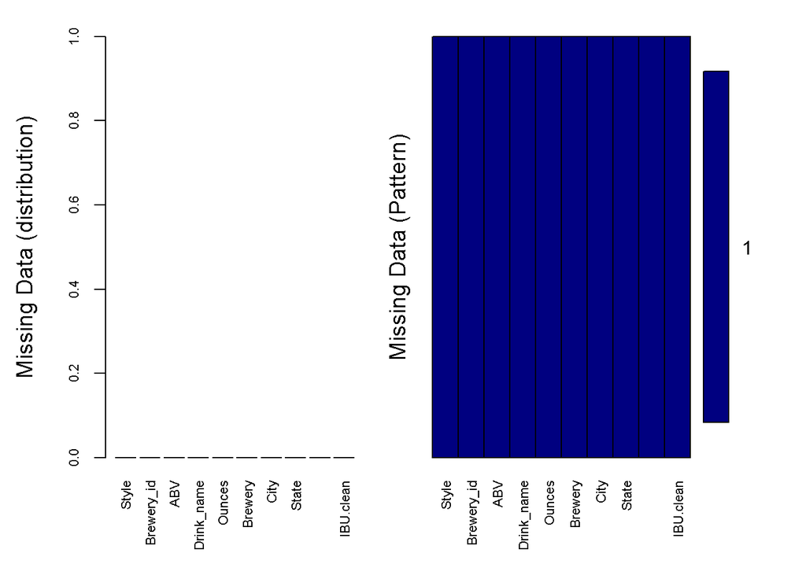

```
##
##  Variables sorted by number of missings:
##             Variable Count
##                Style     0
##           Brewery_id     0
##                  ABV     0
##           Drink_name     0
##               Ounces     0
##              Brewery     0
##                 City     0
##                State     0
##  median_IBU_by_style     0
##            IBU.clean     0
```

```
##     Style             Brewery_id       ABV           Drink_name
##  Length:2348        Min.   :  1   Min.   :0.02700   Length:2348
##  Class :character   1st Qu.: 92   1st Qu.:0.05000   Class :character
##  Mode  :character   Median :204   Median :0.05600   Mode  :character
##                     Mean   :231   Mean   :0.05967
##                     3rd Qu.:366   3rd Qu.:0.06700
##                     Max.   :558   Max.   :0.12800
##
##      Ounces        Brewery              City               State
##  Min.   : 8.40   Length:2348        Length:2348        CO     : 258
##  1st Qu.:12.00   Class :character   Class :character   CA     : 181
##  Median :12.00   Mode  :character   Mode  :character   MI     : 146
##  Mean   :13.56                                         IN     : 139
##  3rd Qu.:16.00                                         TX     : 129
##  Max.   :32.00                                         OR     : 115
##                                                        (Other):1380
##  median_IBU_by_style   IBU.clean
##  Min.   : 8.00       Min.   :  3.57
##  1st Qu.:21.00       1st Qu.: 21.00
##  Median :30.00       Median : 32.00
##  Mean   :40.03       Mean   : 40.46
##  3rd Qu.:69.00       3rd Qu.: 60.00
##  Max.   :96.00       Max.   :138.00
##
```

# 4. Median ABV and IBU per state (See output for values)

We can see that there is a difference between states for median IBU and ABV. This is likely due to a variety of reasons such as local laws, climate, demographics, local diet, income per capita, etc. For example, West Virginia has the highest median IBU and New Hampshire has the lowest median IBU per state. Kentucky has the highest median ABV. Utah has the lowest ABV per state (state law mandates 4.0% for most beers)

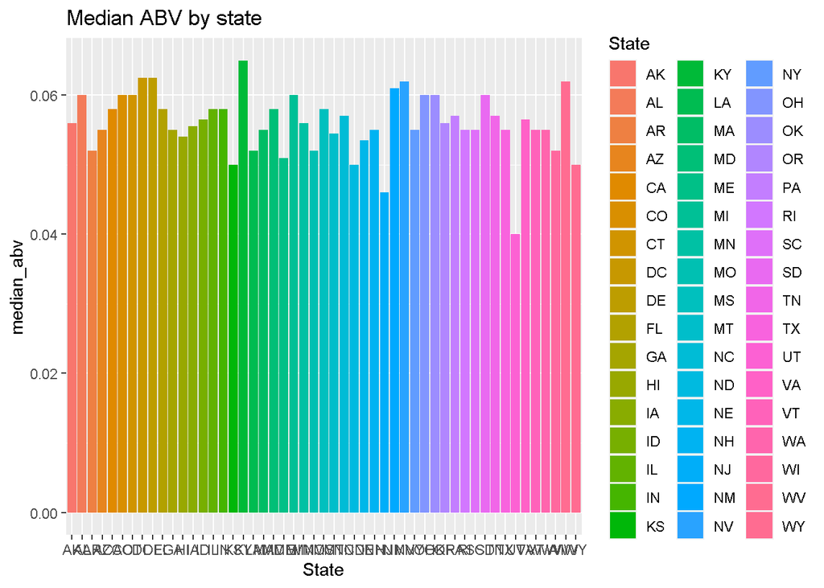

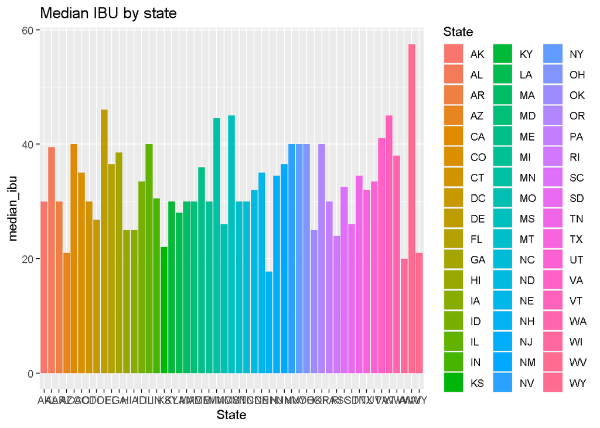

[output not shown]

[output not shown]

# 5. Which state has the maximum alcoholic (ABV) beer? Which state has the most bitter (IBU) beer? (See output for values)

- Colorado has the max ABV at 0.128.
- Oregon has the most IBU at 138.

| Style | Brewery_id | ABV | Drink_name | Ounces | Brewery | City | State | median_IBU_by_style | IBU.clean |
| --- | --- | --- | --- | --- | --- | --- | --- | --- | --- |
| Quadrupel (Quad) | 52 | 0.128 | Lee Hill Series Vol. 5 - Belgian Style Quadrupel Ale | 19.2 | Upslope Brewing Company | Boulder | CO | 24 | 24 |
| English Barleywine | 2 | 0.125 | London Balling | 16.0 | Against the Grain Brewery | Louisville | KY | 60 | 80 |
| Russian Imperial Stout | 18 | 0.120 | Csar | 16.0 | Tin Man Brewing Company | Evansville | IN | 94 | 90 |
| Rye Beer | 52 | 0.104 | Lee Hill Series Vol. 4 - Manhattan Style Rye Ale | 19.2 | Upslope Brewing Company | Boulder | CO | 57 | 57 |
| Baltic Porter | 47 | 0.100 | 4Beans | 12.0 | Sixpoint Craft Ales | Brooklyn | NY | 52 | 52 |
| American Barleywine | 310 | 0.099 | Old Devil’s Tooth | 12.0 | Sockeye Brewing Company | Boise | ID | 96 | 100 |

```
## [1] "Highest ABV State"
```

```
##              Style Brewery_id   ABV
## 1 Quadrupel (Quad)         52 0.128
##                                             Drink_name Ounces
## 1 Lee Hill Series Vol. 5 - Belgian Style Quadrupel Ale   19.2
##                   Brewery    City State median_IBU_by_style IBU.clean
## 1 Upslope Brewing Company Boulder    CO                  24        24
```

| Style | Brewery_id | ABV | Drink_name | Ounces | Brewery | City | State | median_IBU_by_style | IBU.clean |
| --- | --- | --- | --- | --- | --- | --- | --- | --- | --- |
| American Double / Imperial IPA | 375 | 0.082 | Bitter Bitch Imperial IPA | 12 | Astoria Brewing Company | Astoria | OR | 90.5 | 138 |
| American IPA | 345 | 0.059 | Troopers Alley IPA | 12 | Wolf Hills Brewing Company | Abingdon | VA | 69.0 | 135 |
| American Double / Imperial IPA | 231 | 0.090 | Dead-Eye DIPA | 16 | Cape Ann Brewing Company | Gloucester | MA | 90.5 | 130 |
| American Double / Imperial IPA | 100 | 0.089 | Bay of Bengal Double IPA (2014) | 12 | Christian Moerlein Brewing Company | Cincinnati | OH | 90.5 | 126 |
| American Double / Imperial IPA | 273 | 0.080 | Heady Topper | 16 | The Alchemist | Waterbury | VT | 90.5 | 120 |
| American Double / Imperial IPA | 62 | 0.097 | Abrasive Ale | 16 | Surly Brewing Company | Brooklyn Center | MN | 90.5 | 120 |

```
## [1] "Highest IBU State"
```

```
##                            Style Brewery_id   ABV                Drink_name
## 1 American Double / Imperial IPA        375 0.082 Bitter Bitch Imperial IPA
##   Ounces                 Brewery    City State median_IBU_by_style IBU.clean
## 1     12 Astoria Brewing Company Astoria    OR                90.5       138
```

# 6. Summary statistics and Histogram for ABV and IBU

As can be seen IBU is right skewed. The distribution per state seems fairly similar. Most of the beer is located around the lower IBU which could indicate that more bitter beer is less popular and thus sold less. Similarly the distribution of ABV is right skewed as we would expect for values that can only be positive. It seems that most popular beers will have around 5% ABV so that is the peak we see in the middle. Minimum ABV is 0.027, the maximum ABV is 0.128. The minimum being 2.7 suggests no non-alcoholic beer is present in our dataset and that the lowest ABV is similar to a Raddler or a VERY weak session ale. The highest ABV is consistent with Barley wines, Imperial Stouts, or other High gravity beers. The inter-quartile range for the mean 50% of beers ranges from .050 to .0670 suggesting most craft beers have a fairly predictable ABV.

|  | Style | Brewery_id | ABV | Drink_name | Ounces | Brewery | City | State | median_IBU_by_style | IBU.clean |
| --- | --- | --- | --- | --- | --- | --- | --- | --- | --- | --- |
|  | Length:2348 | Min. : 1 | Min. :0.02700 | Length:2348 | Min. : 8.40 | Length:2348 | Length:2348 | CO : 258 | Min. : 8.00 | Min. : 3.57 |
|  | Class :character | 1st Qu.: 92 | 1st Qu.:0.05000 | Class :character | 1st Qu.:12.00 | Class :character | Class :character | CA : 181 | 1st Qu.:21.00 | 1st Qu.: 21.00 |
|  | Mode :character | Median :204 | Median :0.05600 | Mode :character | Median :12.00 | Mode :character | Mode :character | MI : 146 | Median :30.00 | Median : 32.00 |
|  | NA | Mean :231 | Mean :0.05967 | NA | Mean :13.56 | NA | NA | IN : 139 | Mean :40.03 | Mean : 40.46 |
|  | NA | 3rd Qu.:366 | 3rd Qu.:0.06700 | NA | 3rd Qu.:16.00 | NA | NA | TX : 129 | 3rd Qu.:69.00 | 3rd Qu.: 60.00 |
|  | NA | Max. :558 | Max. :0.12800 | NA | Max. :32.00 | NA | NA | OR : 115 | Max. :96.00 | Max. :138.00 |
|  | NA | NA | NA | NA | NA | NA | NA | (Other):1380 | NA | NA |

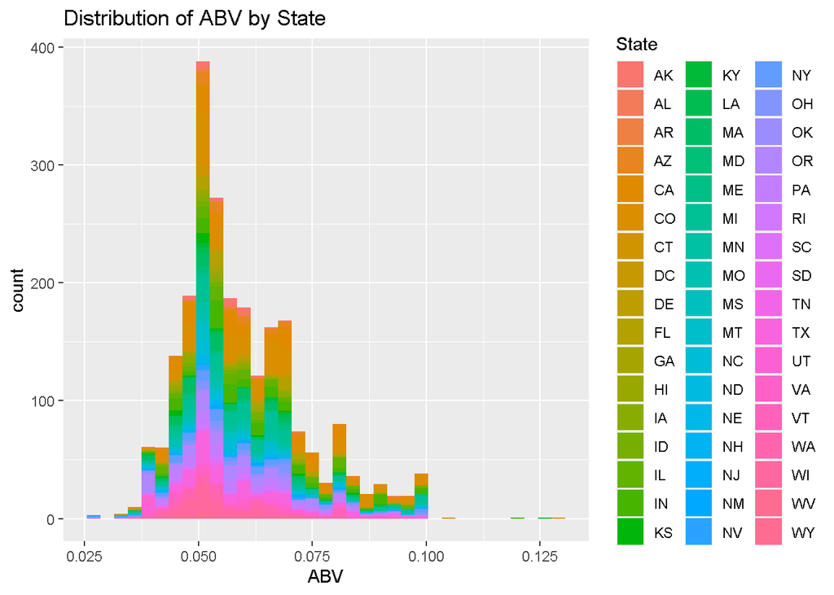

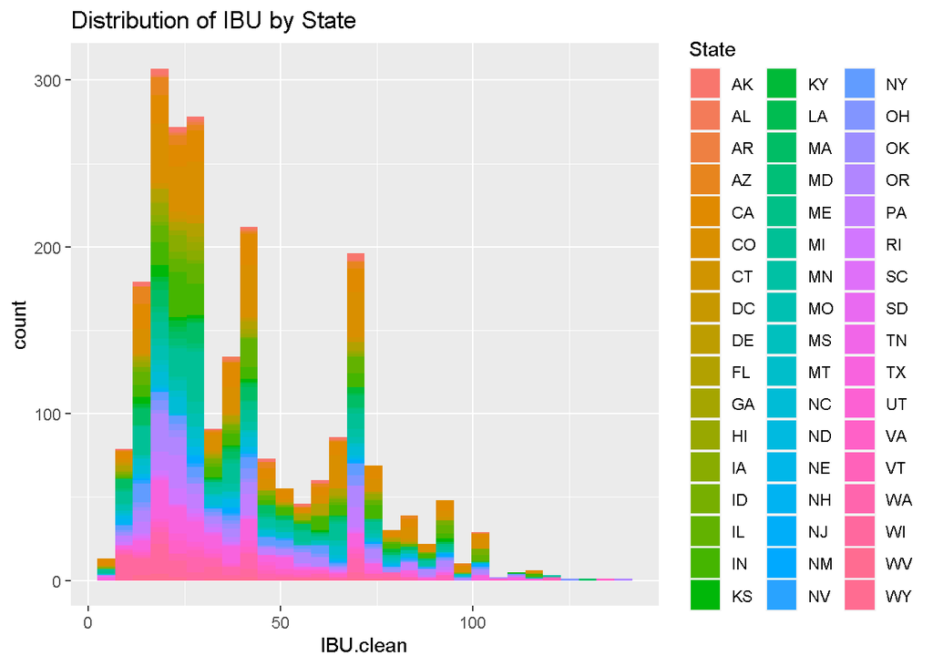

# 7. Relationship between the bitterness of the beer and its alcoholic content

### As can be seen, here are the scatter plots for IBU vs ABV, colorized by state with a ordinary least squares regression line.

These plots suggest visually that there is indeed a linear relationship between IBU and ABV and that there are some outliers at the very high and low ABV values.

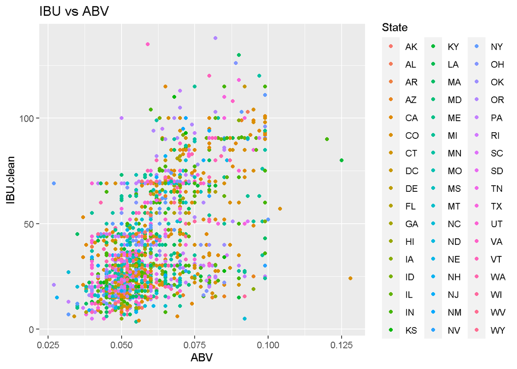

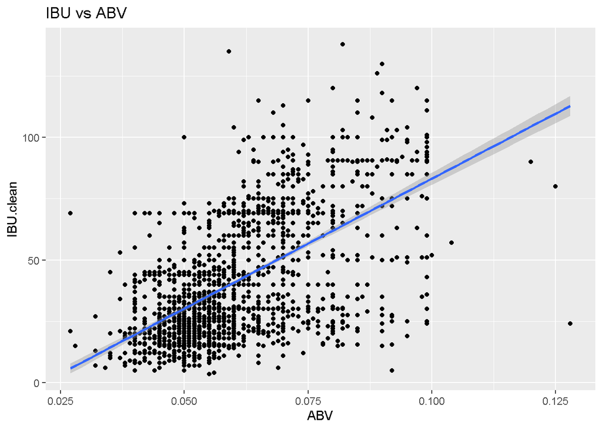

### Linear Regression

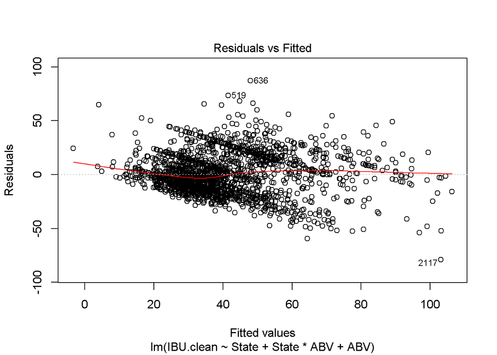

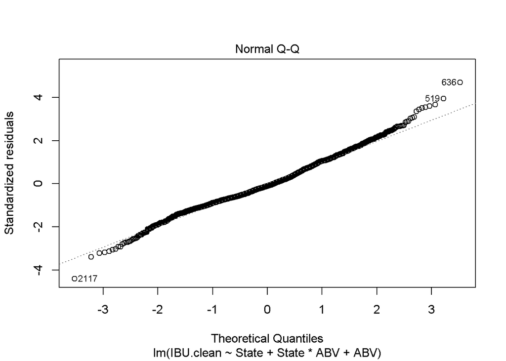

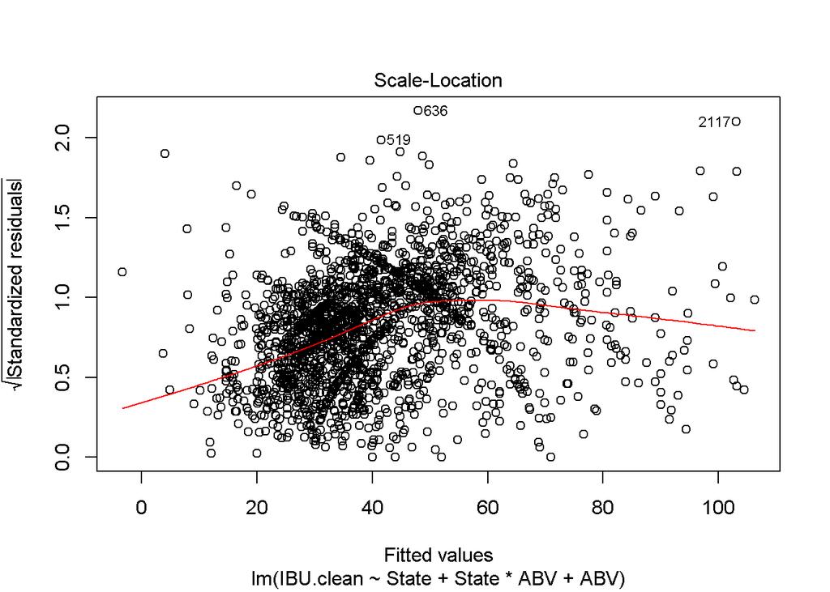

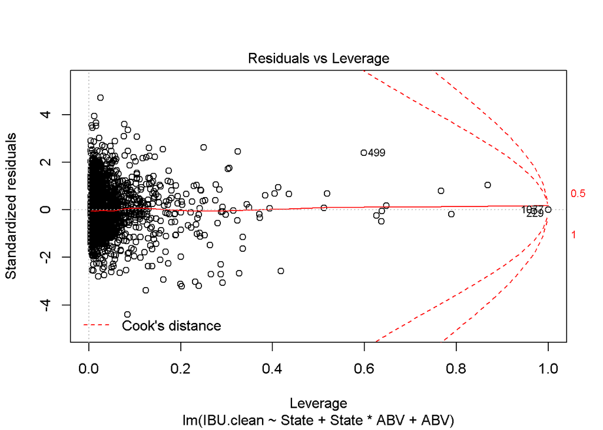

```
##                     2.5 %        97.5 %
## (Intercept) -2.029943e+02 -5.557743e+01
## StateAL     -3.171919e+01  1.610959e+02
## StateAR      1.873105e+01  3.022028e+02
## StateAZ      4.223290e+01  1.995165e+02
## StateCA      2.426679e+01  1.735989e+02
## StateCO      3.969322e+01  1.885393e+02
## StateCT      2.709379e+01  1.850218e+02
## StateDC     -3.592496e+01  1.596376e+02
## StateDE     -4.996493e+00  4.555682e+02
## StateFL     -8.545280e+00  1.503379e+02
## StateGA     -1.517081e+01  1.858964e+02
## StateHI      9.646861e+00  1.784723e+02
## StateIA      3.499440e+01  1.973795e+02
## StateID      1.044196e+01  1.676403e+02
## StateIL      1.045292e+01  1.619778e+02
## StateIN      4.723884e+01  1.971809e+02
## StateKS      1.470119e+01  1.787877e+02
## StateKY      4.877115e+01  2.065952e+02
## StateLA      3.073658e+00  1.705897e+02
## StateMA      1.170816e+01  1.650841e+02
## StateMD      3.120150e+01  2.018471e+02
## StateME      1.643328e+01  1.741833e+02
## StateMI      6.025551e+01  2.102381e+02
## StateMN      2.235158e+01  1.760193e+02
## StateMO     -5.508943e+00  1.565254e+02
## StateMS     -5.005935e+00  1.768878e+02
## StateMT      2.745614e-02  1.707954e+02
## StateNC      4.231389e+01  1.961367e+02
## StateND     -9.828384e+01  1.894470e+02
## StateNE      2.539617e+01  1.882393e+02
## StateNH      8.715583e+00  2.110638e+02
## StateNJ      1.506322e+01  1.810460e+02
## StateNM     -6.668006e+01  1.304972e+02
## StateNV      4.021690e+01  2.140915e+02
## StateNY      2.442976e+01  1.761810e+02
## StateOH      2.997580e+01  1.861851e+02
## StateOK      1.152842e+01  1.794636e+02
## StateOR      5.000986e+00  1.560456e+02
## StatePA      6.221629e+01  2.136222e+02
```

[output cut: 48 more lines]

```
## StateOK:ABV -3.327548e+03 -3.781808e+02
## StateOR:ABV -2.668915e+03  2.787855e+01
## StatePA:ABV -3.831445e+03 -1.136083e+03
## StateRI:ABV -3.684933e+03 -8.084058e+02
## StateSC:ABV -3.272199e+03 -3.885799e+02
## StateSD:ABV -4.912777e+03 -4.379245e+02
## StateTN:ABV -4.008628e+03  1.657986e+03
## StateTX:ABV -2.939022e+03 -2.571151e+02
## StateUT:ABV -3.625949e+03 -8.424689e+02
## StateVA:ABV -2.815656e+03  4.590502e+01
## StateVT:ABV -2.803556e+03  4.054335e-02
## StateWA:ABV -3.500037e+03 -7.273079e+02
## StateWI:ABV -3.394402e+03 -6.088908e+02
## StateWV:ABV -5.664767e+03  5.061681e+03
## StateWY:ABV -2.961487e+03  4.869884e+02
```

```
##
## Call:
## lm(formula = IBU.clean ~ State + State * ABV + ABV, data = bdat.imputed.IBU.clean)
##
## Residuals:
##     Min      1Q  Median      3Q     Max
## -79.146 -12.212  -1.991  12.028  87.085
##
## Coefficients:
##             Estimate Std. Error t value Pr(>|t|)
## (Intercept)  -129.29      37.59  -3.440 0.000593 ***
## StateAL        64.69      49.16   1.316 0.188368
## StateAR       160.47      72.28   2.220 0.026506 *
## StateAZ       120.87      40.10   3.014 0.002606 **
## StateCA        98.93      38.08   2.598 0.009428 **
## StateCO       114.12      37.95   3.007 0.002668 **
## StateCT       106.06      40.27   2.634 0.008500 **
## StateDC        61.86      49.86   1.241 0.214906
## StateDE       225.29     117.43   1.918 0.055178 .
## StateFL        70.90      40.51   1.750 0.080241 .
## StateGA        85.36      51.27   1.665 0.096033 .
## StateHI        94.06      43.05   2.185 0.028982 *
## StateIA       116.19      41.40   2.806 0.005056 **
## StateID        89.04      40.08   2.222 0.026413 *
## StateIL        86.22      38.63   2.232 0.025741 *
## StateIN       122.21      38.23   3.197 0.001410 **
## StateKS        96.74      41.84   2.312 0.020845 *
## StateKY       127.68      40.24   3.173 0.001529 **
## StateLA        86.83      42.71   2.033 0.042172 *
## StateMA        88.40      39.11   2.260 0.023891 *
## StateMD       116.52      43.51   2.678 0.007457 **
## StateME        95.31      40.22   2.370 0.017892 *
## StateMI       135.25      38.24   3.537 0.000413 ***
## StateMN        99.19      39.18   2.531 0.011425 *
## StateMO        75.51      41.31   1.828 0.067731 .
## StateMS        85.94      46.38   1.853 0.064002 .
## StateMT        85.41      43.54   1.962 0.049926 *
## StateNC       119.23      39.22   3.040 0.002394 **
## StateND        45.58      73.36   0.621 0.534452
## StateNE       106.82      41.52   2.573 0.010155 *
```

[output cut: 63 more lines]

```
## StateTN:ABV -1175.32    1444.81  -0.813 0.416031
## StateTX:ABV -1598.07     683.80  -2.337 0.019525 *
## StateUT:ABV -2234.21     709.70  -3.148 0.001665 **
## StateVA:ABV -1384.88     729.61  -1.898 0.057811 .
## StateVT:ABV -1401.76     714.83  -1.961 0.050007 .
## StateWA:ABV -2113.67     706.96  -2.990 0.002822 **
## StateWI:ABV -2001.65     710.22  -2.818 0.004869 **
## StateWV:ABV  -301.54    2734.91  -0.110 0.912216
## StateWY:ABV -1237.25     879.26  -1.407 0.159519
## ---
## Signif. codes:  0 '***' 0.001 '**' 0.01 '*' 0.05 '.' 0.1 ' ' 1
##
## Residual standard error: 18.75 on 2246 degrees of freedom
## Multiple R-squared:  0.4258, Adjusted R-squared:    0.4
## F-statistic: 16.49 on 101 and 2246 DF,  p-value: < 2.2e-16
```

# 8. Difference with respect to IBU and ABV between IPAs and other Ales

To investigate the difference between `IBU` and `ABV` for `IPA's vs OtherAles` we first perform some nominal data cleanup and visualize IBU vs ABV for `IPA's vs otherAles`. We then use KNN to classify style, either `IPA` or `otherAle`, to highlight that there is a significant difference between the relationship of IBU and ABV for `IPA's` and `otherAles`

### Data Prep and Visualization

1. Filter out all data that is not an `Ale`. Then bucket anything with `IPA` or `India Pale Ale` as `IPA` and all other beers with the word `Ale` in their style as `OtherAle`.
2. Plot distributions for ABV for `IPA's` and `otherAles`
3. Then plot IBU and ABV for `IPA's` and `otherAles` for IPA’s and OtherALes

**Note: American Pale Ale is VERY similar to IPA but we call it “other” ale**

```
##                    Abbey Single Ale                             Altbier
##                                   2                                  13
##              American Adjunct Lager            American Amber / Red Ale
##                                  18                                 132
##          American Amber / Red Lager                 American Barleywine
##                                  28                                   3
##                  American Black Ale                 American Blonde Ale
##                                  36                                 108
##                  American Brown Ale             American Dark Wheat Ale
##                                  70                                   7
##      American Double / Imperial IPA  American Double / Imperial Pilsner
##                                 105                                   2
##    American Double / Imperial Stout           American India Pale Lager
##                                   9                                   3
##                        American IPA             American Pale Ale (APA)
##                                 423                                 244
##                 American Pale Lager             American Pale Wheat Ale
##                                  38                                  96
##                    American Pilsner                     American Porter
##                                  25                                  67
##                      American Stout                 American Strong Ale
##                                  39                                  14
##                  American White IPA                   American Wild Ale
##                                  11                                   6
##                       Baltic Porter                    Belgian Dark Ale
##                                   6                                  11
##                         Belgian IPA                    Belgian Pale Ale
##                                  18                                  24
##             Belgian Strong Dark Ale             Belgian Strong Pale Ale
##                                   6                                   7
##                  Berliner Weissbier                      Bière de Garde
##                                  11                                   7
##                                Bock      California Common / Steam Beer
##                                   7                                   6
##                          Chile Beer                           Cream Ale
##                                   3                                  29
##                      Czech Pilsener                          Doppelbock
##                                  28                                   7
##           Dortmunder / Export Lager                              Dubbel
##                                   6                                   5
```

[output cut: 37 more lines]

```
##                                   4                                   3
##                          Roggenbier              Russian Imperial Stout
##                                   2                                  11
##                            Rye Beer              Saison / Farmhouse Ale
##                                  18                                  52
##                         Schwarzbier              Scotch Ale / Wee Heavy
##                                   9                                  15
##            Scottish-Style Amber Ale                        Scottish Ale
##                                   1                                  19
##                         Smoked Beer                              Tripel
##                                   1                                  11
##                        Vienna Lager                           Wheat Ale
##                                  20                                   1
##                       Winter Warmer                             Witbier
##                                  15                                  51
```

```
##      Style Brewery_id   ABV                   Drink_name Ounces
## 1 OtherAle         58 0.049      Abbey's Single (2015- )     12
## 2 OtherAle         58 0.049 Abbey's Single Ale (Current)     12
## 3 OtherAle        361 0.061                  Hot Rod Red     12
## 4 OtherAle        553 0.056      Mickey Finn's Amber Ale     12
## 5 OtherAle        102 0.052          Hurricane Amber Ale     12
## 6 OtherAle         83 0.052    Fat Tire Amber Ale (2011)     12
##                           Brewery          City State median_IBU_by_style
## 1                 Destihl Brewery   Bloomington    IL                  22
## 2                 Destihl Brewery   Bloomington    IL                  22
## 3         Aviator Brewing Company Fuquay-Varina    NC                  30
## 4           Mickey Finn's Brewery  Libertyville    IL                  30
## 5 Coastal Extreme Brewing Company       Newport    RI                  30
## 6     New Belgium Brewing Company  Fort Collins    CO                  30
##   IBU.clean
## 1        22
## 2        22
## 3        41
## 4        30
## 5        24
## 6        18
```

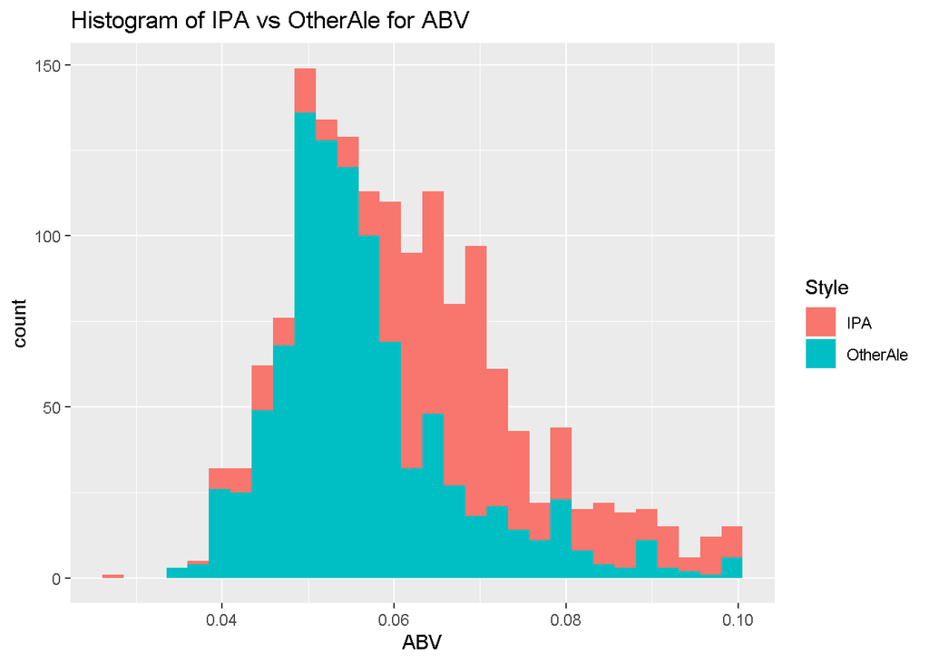

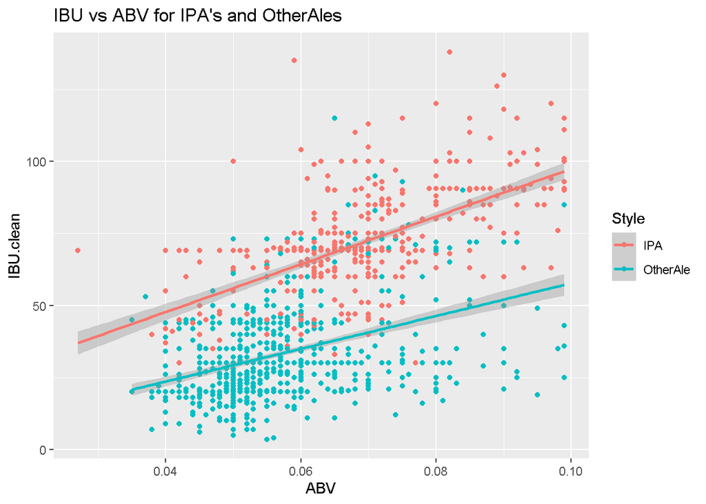

```
##    Length     Class      Mode
##      2348 character character
```

### Test split

Split the data into 85% train and 15% test. Only train our algorithms on training data with crossvalidation. Use test split only for accuracy and prediction metric calculation.

### KNN for `IPA's` vs `Other Ales`

```
## Confusion Matrix and Statistics
##
##           classifications
##            IPA OtherAle
##   IPA       66        8
##   OtherAle  16      140
##
##                Accuracy : 0.8957
##                  95% CI : (0.8487, 0.932)
##     No Information Rate : 0.6435
##     P-Value [Acc > NIR] : <2e-16
##
##                   Kappa : 0.7675
##
##  Mcnemar's Test P-Value : 0.153
##
##             Sensitivity : 0.8049
##             Specificity : 0.9459
##          Pos Pred Value : 0.8919
##          Neg Pred Value : 0.8974
##              Prevalence : 0.3565
##          Detection Rate : 0.2870
##    Detection Prevalence : 0.3217
##       Balanced Accuracy : 0.8754
##
##        'Positive' Class : IPA
##
```

### OLS Multiple Linear Regression for `IPA's` vs `Other Ales`

Use least squared multiple linear regression to highlight specific relationships between IBU and ABV for style IPA and style otherAle. - NOTE: make the unit increase in interpretation be in terms of .01 unit increase in ABV

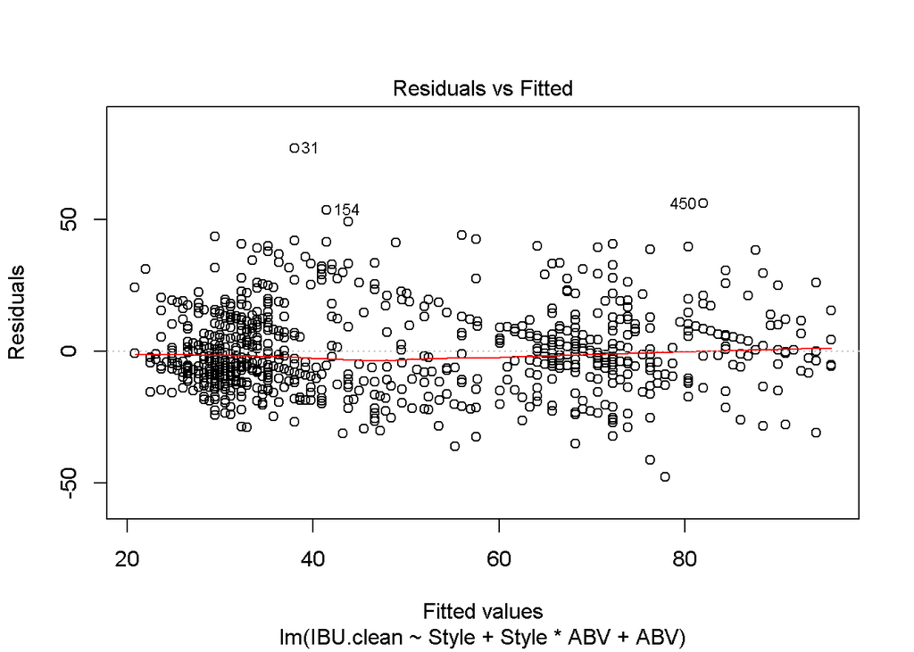

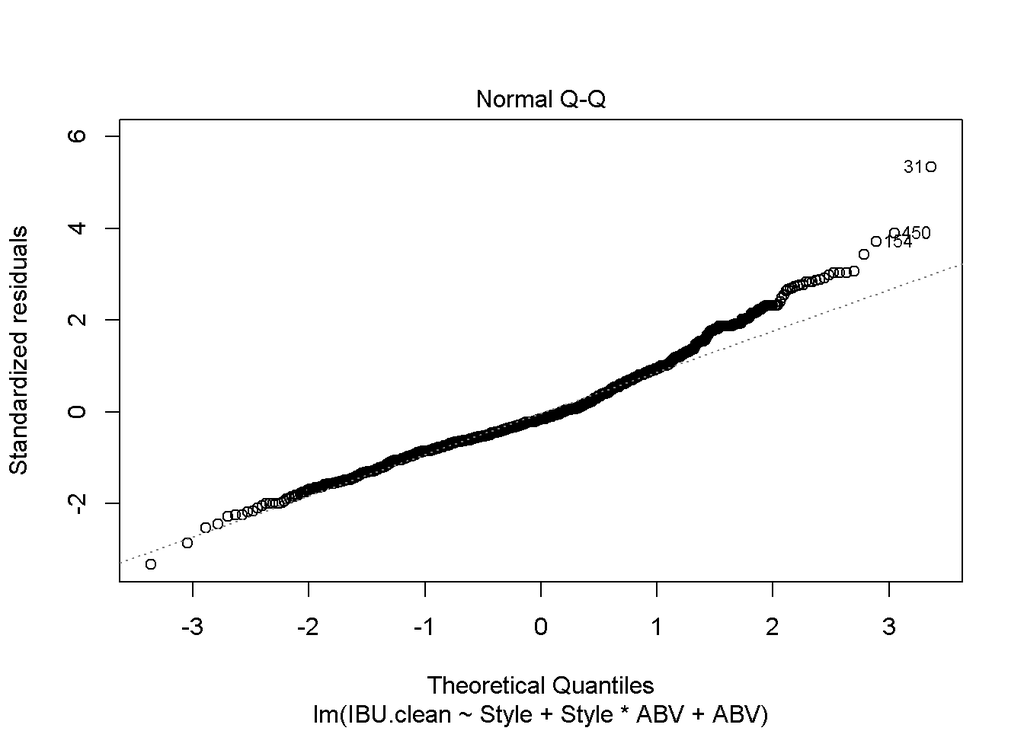

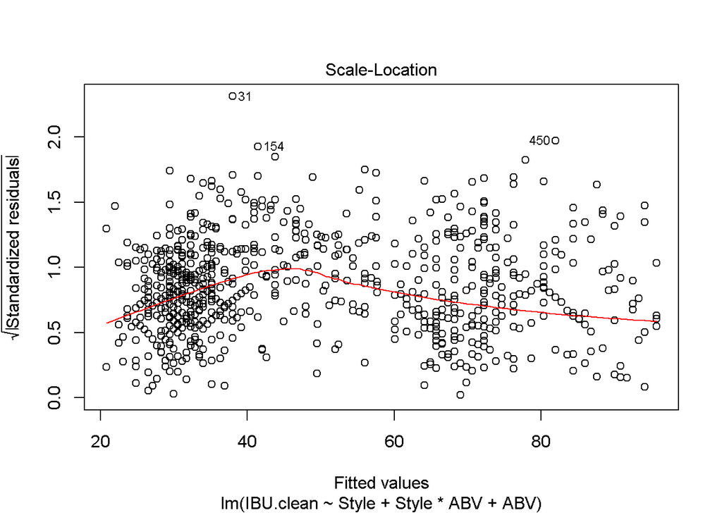

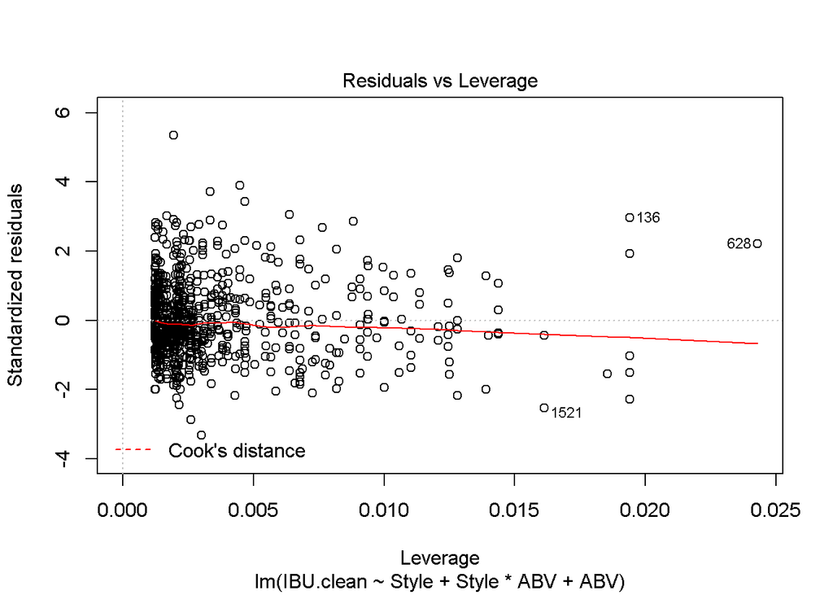

```
##                        2.5 %     97.5 %
## (Intercept)          8.43918  22.634170
## StyleOtherAle      -23.62164  -6.044308
## ABV                707.65116 912.224759
## StyleOtherAle:ABV -371.92932 -99.601412
```

```
##
## Call:
## lm(formula = IBU.clean ~ Style + Style * ABV + ABV, data = bdat.IPA.Vs.Ales.train)
##
## Residuals:
##     Min      1Q  Median      3Q     Max
## -47.902  -9.135  -2.283   8.278  76.975
##
## Coefficients:
##                   Estimate Std. Error t value Pr(>|t|)
## (Intercept)         15.537      3.618   4.294 1.88e-05 ***
## StyleOtherAle      -14.833      4.480  -3.311 0.000955 ***
## ABV                809.938     52.139  15.534  < 2e-16 ***
## StyleOtherAle:ABV -235.765     69.408  -3.397 0.000702 ***
## ---
## Signif. codes:  0 '***' 0.001 '**' 0.01 '*' 0.05 '.' 0.1 ' ' 1
##
## Residual standard error: 14.42 on 1296 degrees of freedom
## Multiple R-squared:  0.6575, Adjusted R-squared:  0.6567
## F-statistic: 829.3 on 3 and 1296 DF,  p-value: < 2.2e-16
```

### Conclusion:

That said, it can be noted that IPA’s generally have a higher ABV (IBU not fixed). The skew of IPA’s toward higher ABV could also be due to the fact beer drinkers generally drink fewer IPA’s and are willing to spend more money on them. As such, to achieve the same ‘buzz’ the discerning IPA drinker will gravitate towards higher IBU AND Higher ABV.

# 9. We will knock your socks off!

### Data Cleanup and Visualization

1. Filter out all ales that are not either `12` or `16` ounces in volume.
2. We plot the ratios of `12` vs `16` ounce Ales for each state.

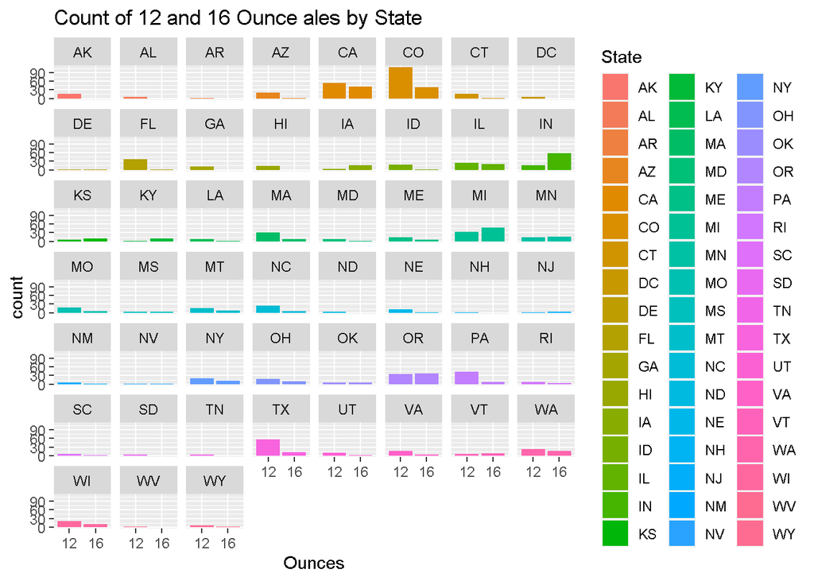

### Analysis: KNN & confusion matrix

```
## Confusion Matrix and Statistics
##
##     classifications
##       12  16
##   12 127  13
##   16  51  36
##
##                Accuracy : 0.7181
##                  95% CI : (0.6547, 0.7756)
##     No Information Rate : 0.7841
##     P-Value [Acc > NIR] : 0.9925
##
##                   Kappa : 0.3499
##
##  Mcnemar's Test P-Value : 3.746e-06
##
##             Sensitivity : 0.7135
##             Specificity : 0.7347
##          Pos Pred Value : 0.9071
##          Neg Pred Value : 0.4138
##              Prevalence : 0.7841
##          Detection Rate : 0.5595
##    Detection Prevalence : 0.6167
##       Balanced Accuracy : 0.7241
##
##        'Positive' Class : 12
##
```

# Overall Conclusion:

There are several note-worthy relationships in our craft beer dataset. For example, median IBU as well as median ABV per state vary by state for craft beers. When targeting sales of particular states’ craft beer, it would be wise to consider the median IBU and median ABV for the current craft beers in that state.

That said, it can be noted that IPA’s generally have a higher ABV (IBU not fixed). The skew of IPA’s toward higher ABV could also be due to the fact beer drinkers generally drink fewer IPA’s and are willing to spend more money on them. As such, to achieve the same ‘buzz’ the discerning IPA drinker will gravitate towards higher IBU AND higher ABV.

We recommend that Anheuser-Busch InBev stay consistent with established patterns for given states. To tend towards breweries which produce IPA’s and Ale’s that can be accurately predicted with our models above. To favor beers and breweries who have average ABV, IBU, and volume not dissimilar from established norms for that state. Given how strapped the market for craft beer and craft breweires is, the opportuinty is ripe.